# A3: Incarceration

### Introduction

Investigate the population of imprisoned persons per state and county which highlights the locations in the country with high incarceration. Additionally, we compare the proportion of incarcerated Black Americans to white Americans. This emphasizes the gross disproportion of incarcerated individuals and invokes a larger question about racial discrimination in the United States.

### The Dataset

This particular data set provides information about prison populations by county and state within the United States. The data was collected by the Vera Institute to expose patterns of inequality in incarceration data. The data was collected by compiling information from the Bureau of Justice Statistics (BJS) data collections. There are 153811 rows and 36 columns in the data set which is quite large considering that this is only a portion of the real data set. There are definitely some questions of power that need to be addressed when working with data that can be sensitive. It is the programmers responsibility to use this data to contribute to the general knowledge about this population. Data should not be used to push a personal narrative or agenda especially one that is harmful to others. Finally, it is important to note that there are some possible limitations with this data such as the number of missing data from the table musically for certain race categories. Without this data it is difficult to evaluate the accuracy of the provided visualizations and data summaries. This is not to say that this is not a credible source of information but rather something that has faults and should not always be taken at face value. Context is as important as the numerical data itself.

### Trends Over Time Chart

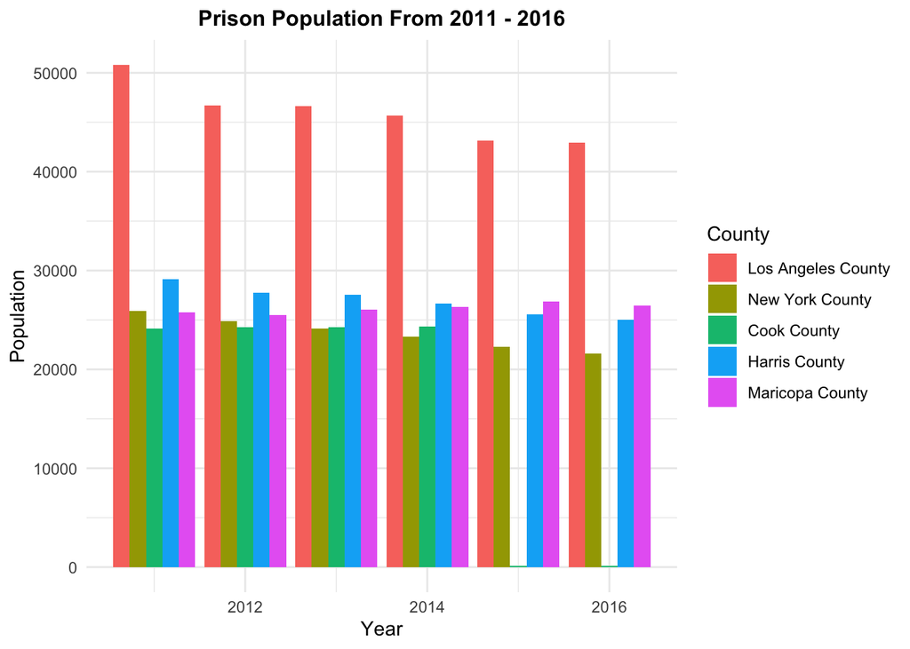

### Variable Comparison Chart

The following chart compares the proportion of incarcerated people to the total population of the corresponding racial group ages 15 to 64. It is essential to include this chart because it shows the disparities between the incarceration rate for Black Americans versus white Americans. While Black Americans are consistently disproportionately imprisoned in comparison to their white counterparts there is a noticeable spike in the early 90s and 2000s. There could be many reasons for this however, I believe that this was due to the influx in social justice movements.

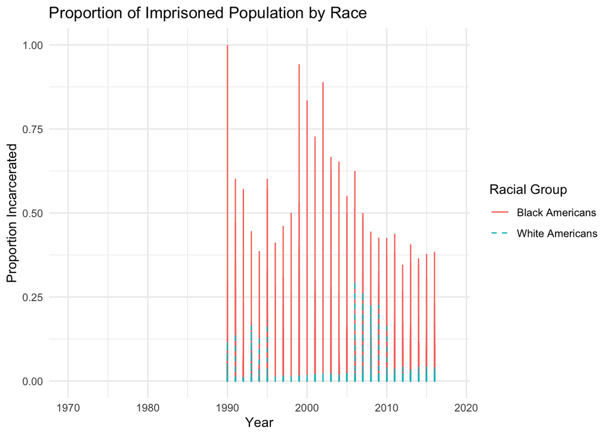

### Map

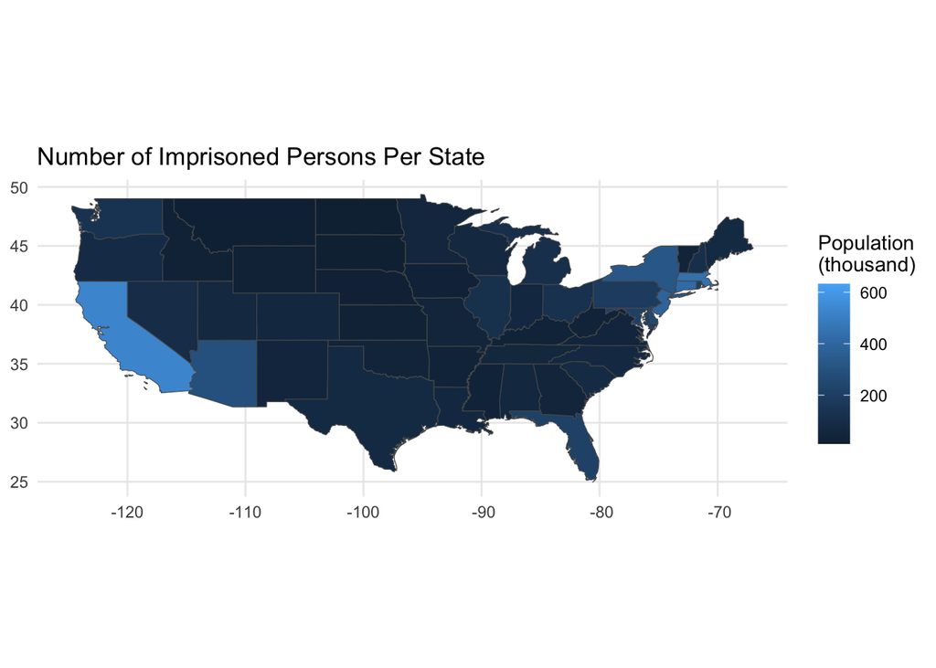